# **Premier League Dynamics (2019-2023): *Manchester City Dominance, Arsenal Rise, Notable Trends*.**

#### **Authors:** Taahaa Dawe, Dhruv Gupta, Ghizlane Rehioui

## Introduction

**EPL (English Premier Leagure)** is the most watched soccer league in the world. The Premier League is the top level of English football. **There are 20 teams in the league, and they move up or down in the league system.** They play against each other twice, once at their home stadium and once at the other team's stadium. The season usually goes from August to May, and each team plays 38 matches. The competition was founded as the FA Premier League on 20 February 1992 following the decision of First Division (top-tier league from 1888 until 1992) clubs to break away from the English Football League. The main reason of choosing EPL data was due to the easy availability of data throughout the years. Being the most popular league in the world, it's easy to find updated data for all the participating teams.

### Objectives:

The research starts with answering the question 'What are the average goals scored per season for the Top 5 EPL teams, and how do those teams rank against each other?'

More generally, this research aims to assess the performance of the Top 5 teams (based on the total goals scored) over the five seasons 2019-2023 while making sure that the performance metrics are varied. Additionally, some hypothesis about Arsenal are tested.

### Research Questions:

- RQ1: Does the observed sample mean of 1.71 for the average goals scored by Arsenal, derived from a dataset, provide statistically significant evidence to reject the claim made on the Manchester City’s Official Website (Cox, 2023) that the average number of goals scored by Arsenal is 2.31?
  - $H_0: \mu = 2.31$,
  - $H_a: \mu \neq 2.31$,
- RQ2: Is there compelling evidence in the dataset to support the claim that there has been a substantial increase in possession for Arsenal in 2022 compared to 2019?
  - $H_0: μ_D = 0$
  - $H_a: μ_D> 0$

## Data

The data utilized for this analysis was scraped from the [FBRef](https://fbref.com/en/) website, a reputable source for football statistics and history. The focus of this project was on gathering and analyzing individual team match data from the Premier League, spanning from the 2019 season to the current season, 2023. In addition to the points table information, we also retrieved crucial shooting statistics for each team in every match from the shooting table. This comprehensive dataset allows for a detailed exploration of team performance metrics and shooting proficiency within the Premier League during the specified timeframe.

NOTE: The following section contains the scraping code as a markdown because scraping takes more than one hour.

```
#Scraping page with requests
import requests standings_url = "https://fbref.com/en/comps/9/Premier-League-Stats"

#Download the page
data = requests.get(standings_url)

print(data) # The response should be '200'. If it gives '429', then try again later as it is rate limiting.

#Parsing HTML links with BeautifulSoup
from bs4 import BeautifulSoup
import time

#Giving the browser time to complete the action and then come up with new sourcecode before reading it using beautifulsoup
soup = BeautifulSoup(data.text)

standings_table = soup.select('table.stats_table')[0]

links = standings_table.find_all('a')
links = [l.get("href") for l in links]
links = [l for l in links if '/squads/' in l]

team_urls = [f"https://fbref.com{l}" for l in links]

#Extracting match stats using pandas and requests
data = requests.get(team_urls[0])

import pandas as pd

matches = pd.read_html(data.text, match="Scores & Fixtures")[0]

#Getting match shooting stats with requests and pandas
soup = BeautifulSoup(data.text)

links = soup.find_all('a')
links = [l.get("href") for l in links]
links = [l for l in links if l and 'all_comps/shooting/' in l]

data = requests.get(f"https://fbref.com%7Blinks%5B0%5D%7D")

shooting = pd.read_html(data.text, match="Shooting")[0]
shooting.head()

#Cleaning and merging scraped data with pandas
shooting.columns = shooting.columns.droplevel()

team_data = matches.merge(shooting[["Date", "Sh", "SoT", "Dist", "FK", "PK", "PKatt"]], on="Date")
team_data.head()

#Scraping data for multiple seasons and teams with a loop
from datetime import datetime

current_year = datetime.now().year
years = list(range(current_year, 2016, -1))
all_matches = []

years #The year'2016' is actually the season '2015-2016'. We use this everywhere which makes working with the data easier.

standings_url = "https://fbref.com/en/comps/9/Premier-League-Stats"

for year in years:

    data = requests.get(standings_url)
    soup = BeautifulSoup(data.text)
    standings_table = soup.select('table.stats_table')[0]

    links = [l.get("href") for l in standings_table.find_all('a')]
    links = [l for l in links if '/squads/' in l]

    team_urls = [f"https://fbref.com{l}" for l in links]

    previous_season = soup.select("a.prev")[0].get("href")
    standings_url = f"https://fbref.com{previous_season}"

for team_url in team_urls:

    team_name = team_url.split("/")[-1].replace("-Stats", "").replace("-", " ")
    data = requests.get(team_url)
    matches = pd.read_html(data.text, match="Scores & Fixtures")[0]
    soup = BeautifulSoup(data.text)

    links = [l.get("href") for l in soup.find_all('a')]
    links = [l for l in links if l and 'all_comps/shooting/' in l]

    data = requests.get(f"https://fbref.com{links[0]}")

    shooting = pd.read_html(data.text, match="Shooting")[0]
    shooting.columns = shooting.columns.droplevel()

    try:
        team_data = matches.merge(shooting[["Date", "Sh", "SoT", "Dist", "FK", "PK", "PKatt"]], on="Date")
    except ValueError:
        continue

    team_data = team_data[team_data["Comp"] == "Premier League"]
    team_data["Season"] = year
    team_data["Team"] = team_name
    all_matches.append(team_data)
    time.sleep(1)

len(all_matches)
match_df = pd.concat(all_matches) # Combining the individual dataframes into a single dataframe

#Data cleaning before converting to csv
match_df.columns = [c.lower() for c in match_df.columns]

match_df.head()
match_df.shape
match_df["team"].value_counts()
match_df.isnull().sum()

match_df.columns
match_df.rename(columns = {'gf':'goals_scored', 'ga':'goals_conceded', 'xg':'expected_goals', 'xga':'expected_assists', 'poss':'possession', 'sh':'shots', 'sot':'shots_on_target', 'dist':'avg_shot_distance', 'fk':'freekicks', 'pk':'penaltykicks', 'pkatt':'penaltykicks_opponent'}, inplace=True )

match_df.head()
match_df.drop(columns=['notes', 'match report'], inplace=True)
match_df.isnull().sum()
match_df.dtypes

match_df[["goals_scored", "goals_conceded"]] = match_df[["goals_scored", "goals_conceded"]].astype(int)

match_df.dtypes
match_df

match_df.to_csv("matches.csv")
```

### Data Description

```python
import pandas as pd
import numpy as np
import matplotlib as plot

# Read in the data
df = pd.read_csv("/content/matches.csv")
df.head(3)
```

|  | Unnamed: 0 | date | time | comp | round | day | venue | result | goals_scored | goals_conceded | ... | formation | referee | shots | shots_on_target | avg_shot_distance | freekicks | penaltykicks | penaltykicks_opponent | season | team |
| --- | --- | --- | --- | --- | --- | --- | --- | --- | --- | --- | --- | --- | --- | --- | --- | --- | --- | --- | --- | --- | --- |
| 0 | 1 | 2023-08-11 | 20:00 | Premier League | Matchweek 1 | Fri | Away | W | 3.0 | 0.0 | ... | 4-2-3-1 | Craig Pawson | 17.0 | 8.0 | 13.9 | 0.0 | 0.0 | 0.0 | 2023 | Manchester City |
| 1 | 3 | 2023-08-19 | 20:00 | Premier League | Matchweek 2 | Sat | Home | W | 1.0 | 0.0 | ... | 4-2-3-1 | Robert Jones | 14.0 | 4.0 | 17.9 | 0.0 | 0.0 | 0.0 | 2023 | Manchester City |
| 2 | 4 | 2023-08-27 | 14:00 | Premier League | Matchweek 3 | Sun | Away | W | 2.0 | 1.0 | ... | 4-2-3-1 | Jarred Gillett | 29.0 | 9.0 | 17.3 | 2.0 | 0.0 | 1.0 | 2023 | Manchester City |

3 rows × 26 columns

```python
df.shape
```

```
(3138, 26)
```

```python
print('First Season is '+str(df['season'].min())+ ' and Last Season is '+str(df['season'].max()))
```

```
First Season is 2019 and Last Season is 2023
```

The scraped data considers only Premier League for the seasons between 2019 and 2023 and is composed of 3138 rows and 26 columns. The next section will deal with the pre-processing of the dataset.

#### *Column Description*

The scraped data consists of 26 columns:

- 'Unnamed: 0': Row number of data
- 'date': Date of the match
- 'time': Time of match
- 'comp': Competition name
- 'round': Matchweek number
- 'day': Day of the week
- 'venue': Where the game is played (Away or Home)
- 'result': W for Win, D for Draw, and L for Loss
- 'goals_scored': Number of goals scored
- 'goals_conceded': Number of goals conceded
- 'opponent': Opponent team name
- 'expected_goals': Expected goals to score
- 'expected_assists': Expected assists provided
- 'possession': Duration for which the team had the ball possession
- 'attendance': Count of audience
- 'captain': Captain of team
- 'formation': Team formation
- 'referee': Referee name
- 'shots': Shots taken by team
- 'shots_on_target': Shots on target by team
- 'avg_shot_distance': Average shot distance
- 'freekicks': Freekicks taken
- 'penaltykicks': Penalties taken
- 'penaltykicks_opponent': Penalties given to opponent
- 'season': Season year
- 'team': Team

## Methods and Analyses

### Data Pre-Processing

Most of the data cleaning was done before saving the scraped data in a .csv file. This section takes another look at the scraped data for research specific cleaning and pre-processing.

```python
df.info()
```

```
<class 'pandas.core.frame.DataFrame'>
RangeIndex: 3138 entries, 0 to 3137
Data columns (total 26 columns):
 #   Column                 Non-Null Count  Dtype
---  ------                 --------------  -----
 0   Unnamed: 0             3138 non-null   int64
 1   date                   3138 non-null   object
 2   time                   3138 non-null   object
 3   comp                   3138 non-null   object
 4   round                  3138 non-null   object
 5   day                    3138 non-null   object
 6   venue                  3138 non-null   object
 7   result                 3138 non-null   object
 8   goals_scored           3138 non-null   float64
 9   goals_conceded         3138 non-null   float64
```

[output cut: 18 more lines]

```python
df.columns
```

```
Index(['Unnamed: 0', 'date', 'time', 'comp', 'round', 'day', 'venue', 'result',
       'goals_scored', 'goals_conceded', 'opponent', 'expected_goals',
       'expected_assists', 'possession', 'attendance', 'captain', 'formation',
       'referee', 'shots', 'shots_on_target', 'avg_shot_distance', 'freekicks',
       'penaltykicks', 'penaltykicks_opponent', 'season', 'team'],
      dtype='object')
```

On a first glance, the data looks mostly clean with only one column *avg_shot_distance* having one missing value and the *attendance* column missing a few values. The column named *Unnamed: 0* can be dropped as it has no relevance.

```python
df.drop(columns='Unnamed: 0', inplace=True)
df.head(3)
```

|  | date | time | comp | round | day | venue | result | goals_scored | goals_conceded | opponent | ... | formation | referee | shots | shots_on_target | avg_shot_distance | freekicks | penaltykicks | penaltykicks_opponent | season | team |
| --- | --- | --- | --- | --- | --- | --- | --- | --- | --- | --- | --- | --- | --- | --- | --- | --- | --- | --- | --- | --- | --- |
| 0 | 2023-08-11 | 20:00 | Premier League | Matchweek 1 | Fri | Away | W | 3.0 | 0.0 | Burnley | ... | 4-2-3-1 | Craig Pawson | 17.0 | 8.0 | 13.9 | 0.0 | 0.0 | 0.0 | 2023 | Manchester City |
| 1 | 2023-08-19 | 20:00 | Premier League | Matchweek 2 | Sat | Home | W | 1.0 | 0.0 | Newcastle Utd | ... | 4-2-3-1 | Robert Jones | 14.0 | 4.0 | 17.9 | 0.0 | 0.0 | 0.0 | 2023 | Manchester City |
| 2 | 2023-08-27 | 14:00 | Premier League | Matchweek 3 | Sun | Away | W | 2.0 | 1.0 | Sheffield Utd | ... | 4-2-3-1 | Jarred Gillett | 29.0 | 9.0 | 17.3 | 2.0 | 0.0 | 1.0 | 2023 | Manchester City |

3 rows × 25 columns

Some data cleaning may be necessary before officially starting the analysis. This includes checking the names of the teams and opponents to make sure they are both proper for future data analysis.

```python
np.sort(df['team'].unique())
```

```
array(['Arsenal', 'Aston Villa', 'Bournemouth', 'Brentford',
       'Brighton and Hove Albion', 'Burnley', 'Chelsea', 'Crystal Palace',
       'Everton', 'Fulham', 'Leeds United', 'Leicester City', 'Liverpool',
       'Luton Town', 'Manchester City', 'Manchester United',
       'Newcastle United', 'Norwich City', 'Nottingham Forest',
       'Sheffield United', 'Southampton', 'Tottenham Hotspur', 'Watford',
       'West Bromwich Albion', 'West Ham United',
       'Wolverhampton Wanderers'], dtype=object)
```

```python
np.sort(df['team'].unique()).size # number of distinct teams in the dataset
```

```
26
```

```python
np.sort(df['opponent'].unique())
```

```
array(['Arsenal', 'Aston Villa', 'Bournemouth', 'Brentford', 'Brighton',
       'Burnley', 'Chelsea', 'Crystal Palace', 'Everton', 'Fulham',
       'Leeds United', 'Leicester City', 'Liverpool', 'Luton Town',
       'Manchester City', 'Manchester Utd', 'Newcastle Utd',
       'Norwich City', "Nott'ham Forest", 'Sheffield Utd', 'Southampton',
       'Tottenham', 'Watford', 'West Brom', 'West Ham', 'Wolves'],
      dtype=object)
```

```python
# Replacing opponent names by corresponding team names (with alike spelling)
opponent_names = np.sort(df['opponent'].unique())
team_names = np.sort(df['team'].unique())
df['opponent'] = df['opponent'].replace(opponent_names, team_names)
```

There are 26 teams in the dataset, which is difficult to analyze. The focus will be given to the Top 5 best teams in the EPL. The choice of the best teams is done based on the total goals scored over the 5 seasons 2019-2023.

```python
ttl_goals_per_teams = df.groupby('team')['goals_scored'].sum().reset_index(name='count').sort_values(by='count', ascending=False)
ttl_goals_per_teams = ttl_goals_per_teams.reset_index()
```

```python
ttl_goals_per_teams[:5]
```

|  | index | team | count |
| --- | --- | --- | --- |
| 0 | 14 | Manchester City | 392.0 |
| 1 | 12 | Liverpool | 334.0 |
| 2 | 21 | Tottenham Hotspur | 281.0 |
| 3 | 0 | Arsenal | 269.0 |
| 4 | 15 | Manchester United | 260.0 |

```python
top = list(ttl_goals_per_teams['team'][:5])
top
```

```
['Manchester City',
 'Liverpool',
 'Tottenham Hotspur',
 'Arsenal',
 'Manchester United']
```

As seen above, the top 5 teams in terms of highest total goals scored (*goals_scored*) over entire period between 2019 and 2023 are as follows, in order from highest to lowest score:

1. Manchester City
2. Liverpool
3. Tottenham Hotspur
4. Arsenal
5. Manchester United

And with this, the rest of the analysis will focus on these Top 5 teams.

#### Distribution and Correlation

There are 25 variables in total. Eight variables are selected for further data exploration in the new data frame `vars_of_interest`.

```python
import pandas as pd
import matplotlib.pyplot as plt
import seaborn as sb
```

```python
df.columns
```

```
Index(['date', 'time', 'comp', 'round', 'day', 'venue', 'result',
       'goals_scored', 'goals_conceded', 'opponent', 'expected_goals',
       'expected_assists', 'possession', 'attendance', 'captain', 'formation',
       'referee', 'shots', 'shots_on_target', 'avg_shot_distance', 'freekicks',
       'penaltykicks', 'penaltykicks_opponent', 'season', 'team'],
      dtype='object')
```

```python
df.columns.size
```

```
25
```

```python
vars_of_interest = df[['season', 'venue', 'result', 'shots', 'shots_on_target', 'possession', 'goals_scored', 'goals_conceded']]
```

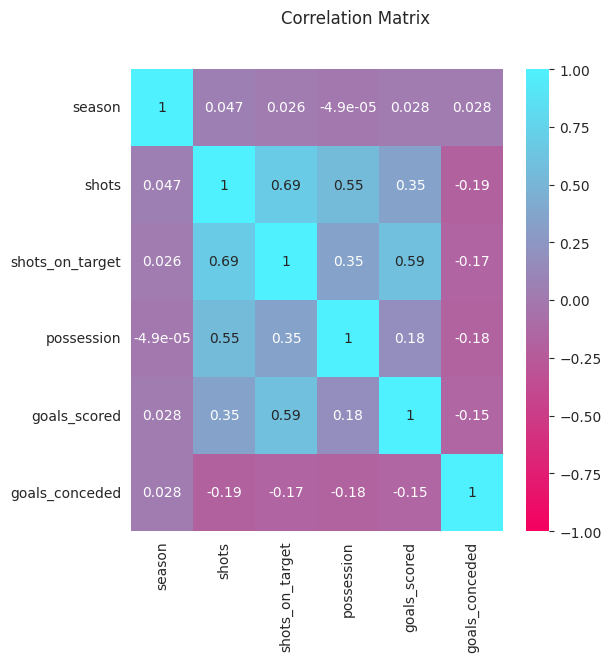

```python
# Correlation Matrix
from matplotlib.colors import LinearSegmentedColormap
corr = vars_of_interest.corr()
plt.figure(figsize=(6,6))
sb.heatmap(corr, cmap=LinearSegmentedColormap.from_list('custom_cmap', ['#f5005f', '#4ff1fe']), annot=True, vmax=1, vmin=-1)
plt.suptitle("Correlation Matrix")
plt.show()
```

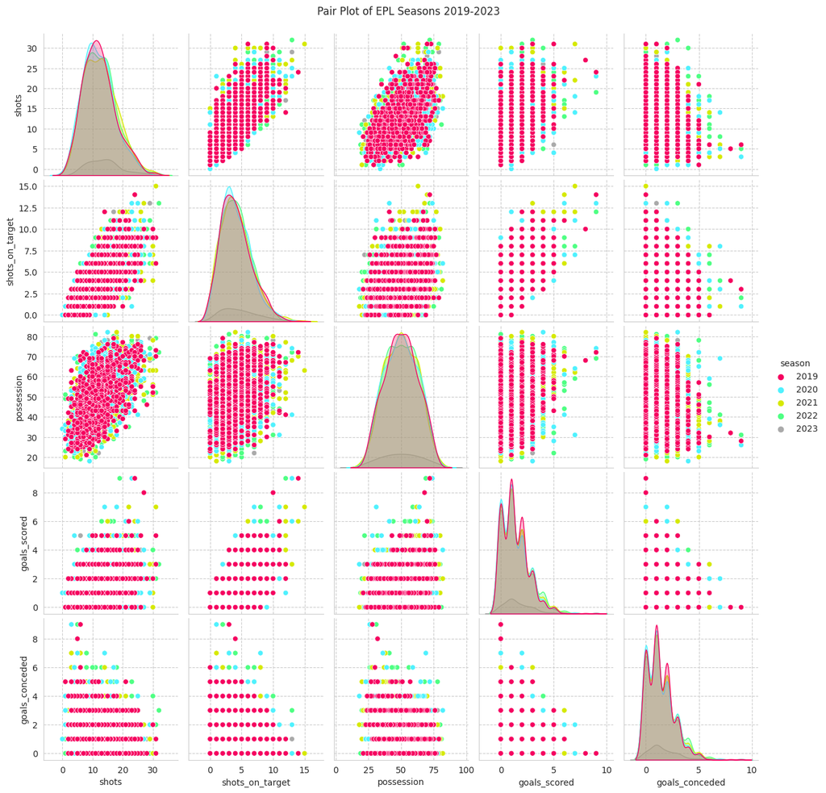

```python
# Pair plot
colors = ['#f5005f', '#4ff1fe', '#d6e900', '#4eff83', '#aaaaaa']
sb.pairplot(vars_of_interest, hue='season', palette = colors)
sb.set_style("whitegrid", {'grid.linestyle': '--'})
plt.suptitle('Pair Plot of EPL Seasons 2019-2023', y=1.02)
```

*Distribution & Correlation Comparison*

## Results

### Exploratory Data Analysis

#### Average goals scored per season for Top 5 EPL:

Given that the year 2023 lacks data, it is more meaningful to plot the average scored goals to have an overall idea on the performance of the Top 5 EPL Teams.

```python
df2 = df[df['team'].isin(top)]
avg_goals = df2.groupby(['team', 'season'])['goals_scored'].mean().reset_index()
avg_goals.sort_values(ascending=[True, False], by=['season', 'goals_scored'], inplace=True)
#avg_goals
```

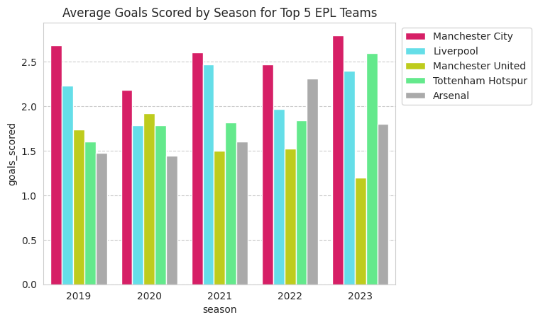

```python
# Seasonally scored goals on average of top 5:
colors = ['#f5005f', '#4ff1fe', '#d6e900', '#4eff83', '#aaaaaa']
sb.barplot(x = avg_goals["season"], y = avg_goals["goals_scored"], hue = "team", palette = colors, data= avg_goals)
plt.title('Average Goals Scored by Season for Top 5 EPL Teams')
plt.legend(loc='upper right', bbox_to_anchor=(1.4, 1))
plt.show()
```

#### Results:

- Similarly to what was found in the Data Preprocessing section, Manchester City ranks first in all seasons, followed by either Liverpool (2019 and 2021), Arsenal (2022), Manchester United (2020), or Tottenham Hotspur (2023) as second place in terms of average scored goals per season.
- On average, it seems that Manchester City, compared to the other top5 teams, is able to maintain the highest seasonal goals scored from one year to the next.
- In 2023, it looks like Tottenham Hotspur is competing fiercely, ranking 2nd on average, as opposed to previous years where it was third or fourth.
- Liverpool is a strong competitor against Manchester City (1st team) and is ranking either 2nd or 3rd at most.
- The average goals scored of Manchester United looks like they are decreasing over time. In the last three years, it is even ranking the last among the Top 5.

#### Percentage of wins over all 5 seasons (2019-2023)

The wins percentage disregards the number of goals scored and focuses on the outcome of the match. The main question it answers is how many matches has a team won out of those they played?

```python
df2 = df[df['team'].isin(top)]
Matches_Played = df2.groupby(['team'])['goals_scored'].count()
Matches_Won = df2[df2['result'] == 'W'].groupby('team')['goals_scored'].count()
Win_Percentage = Matches_Won/Matches_Played*100
```

```python
Win_Percentage.sort_values(ascending=False, inplace=True)
Win_Percentage
```

```
team
Manchester City      73.248408
Liverpool            65.605096
Arsenal              53.503185
Manchester United    50.955414
Tottenham Hotspur    49.681529
Name: goals_scored, dtype: float64
```

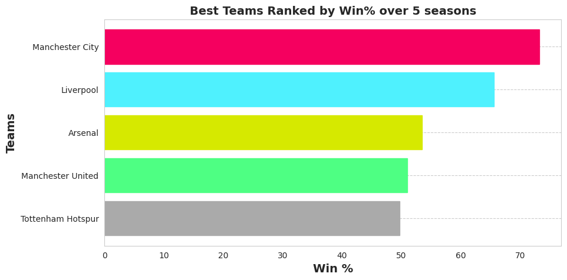

```python
fig = plt.figure(figsize = (10, 5))

# creating the bar plot
barlist = plt.barh(Win_Percentage.index, Win_Percentage, color ='blue')

barlist[0].set_color('#f5005f')
barlist[1].set_color('#4ff1fe')
barlist[2].set_color('#d6e900')
barlist[3].set_color('#4eff83')
barlist[4].set_color('#aaaaaa')

plt.xlabel("Win %",fontweight='bold',fontsize=14.0)
plt.ylabel("Teams",fontweight='bold',fontsize=14.0)
plt.title("Best Teams Ranked by Win% over 5 seasons",fontweight='bold',fontsize=14.0)
plt.grid(axis='x',color = 'white', linestyle = '--')
plt.gca().invert_yaxis()
plt.show()
```

- From the graph above, it looks like Manchester City is the team with the highest percentage of wins over the 5 seasons 2019-2023. Liverpool comes second, followed by Arsenal, Manchester United, and finally Tottenham Hotspur.
- In terms of percentage of wins, there seem to be a few differences from the performance based on the sum of goals scored over the 5 seasons 2019-2023.
- Manchester City (73.25%) and Liverpool (65.61%) remain the first two in terms of percentage of wins as well as total goals scored between the seasons 2019 and 2023. However, Tottenham Hotspurturns (49.68%) out to have the lowest Percentage of Wins among the Top 5 Teams despite having a higher sum of goals scored over the 5 seasons. Arsenal (53.50%) and Manchester United (50.96%)climb up one step each, having a higher win percentage than Tottenham Hotspur.

#### Any difference in performance between Home and Away matches?

Looking at the away vs. home total of goals scored allows for the comparison between how the team performs in both cases and could lead to further investigation on how to imporve team conditions or where the team needs to put more efforts.

```python
df2 = df[df['team'].isin(top)]

Away_Goals = df2[df2['venue'] == 'Away'].groupby(['team'])['goals_scored'].sum()
Home_Goals = df2[df2['venue'] == 'Home'].groupby(['team'])['goals_scored'].sum()
```

```python
df_aw_hm = pd.merge(Home_Goals, Away_Goals, on='team', how='inner')
df_aw_hm.columns={'Home_Goals', 'Away_Goals'}
df_aw_hm.sort_values(by = 'Home_Goals', ascending=False, inplace=True)
df_aw_hm
```

| team | Home_Goals | Away_Goals |
| --- | --- | --- |
| Manchester City | 224.0 | 168.0 |
| Liverpool | 182.0 | 152.0 |
| Arsenal | 155.0 | 114.0 |
| Manchester United | 151.0 | 109.0 |
| Tottenham Hotspur | 150.0 | 131.0 |

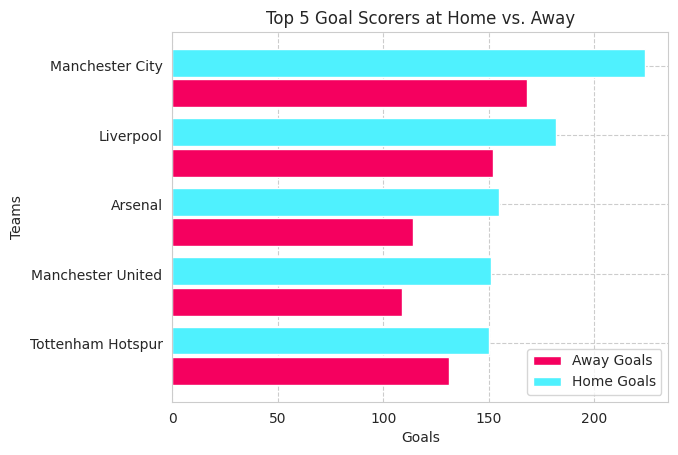

```python
X_axis = np.arange(len(Home_Goals.index))

Teams = df_aw_hm.index

plt.barh(X_axis+0.4, df_aw_hm['Away_Goals'], 0.4, label = 'Away Goals', color = '#f5005f')
plt.barh(X_axis-.04, df_aw_hm['Home_Goals'], 0.4, label = 'Home Goals', color = '#4ff1fe')

plt.xlabel("Goals")
plt.ylabel("Teams")
plt.yticks( X_axis, Teams)
plt.title("Top 5 Goal Scorers at Home vs. Away")
plt.gca().invert_yaxis()
plt.legend()
plt.show()
```

#### Identifying Overperforming Football Teams Based on Goals Scored and Expected Goals (xG)

In the realm of football analytics, Expected Goals (xG) has emerged as a pivotal metric for evaluating team performance. xG quantifies the likelihood of a shot resulting in a goal, taking into account numerous factors like shot location, type, and defensive pressure. Assessing how a team performs relative to their xG provides crucial insights into their offensive efficiency.

##### *Objective*

This analysis seeks to identify overperforming football teams by contrasting their Goals Scored with Expected Goals (xG). Overperforming teams consistently score more goals than their xG projections suggest. The analysis is divided into two main parts:

##### *Part 1: Identifying Top 5 Overperforming Teams Each Year*

In this segment, we dissect individual football seasons to pinpoint teams that have excelled in surpassing their xG projections. The process involves calculating Goals Scored and xG for each team within a season and identifying the top 5 teams with the highest positive differences between Goals Scored and xG.

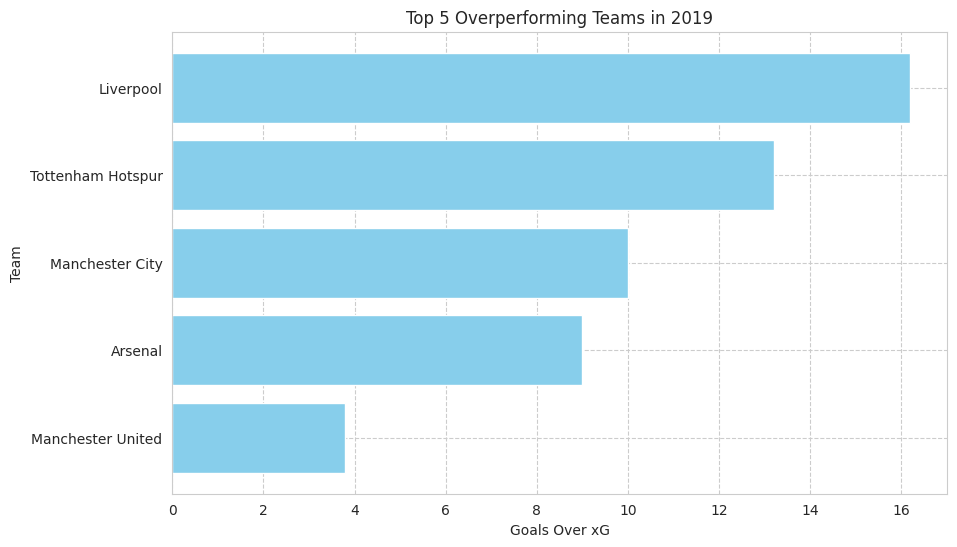

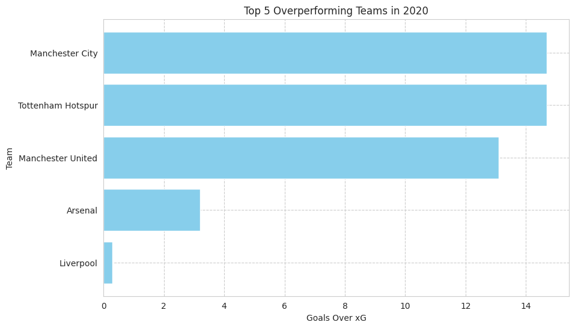

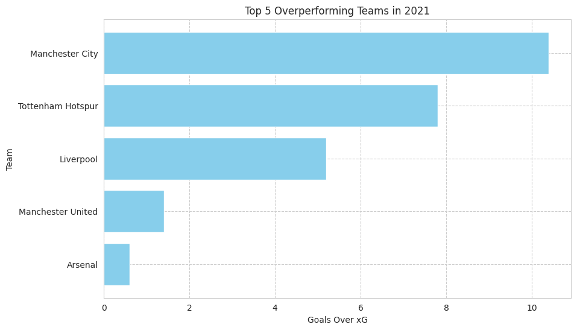

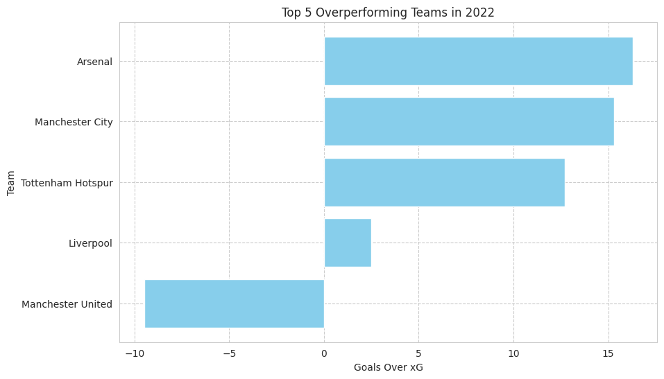

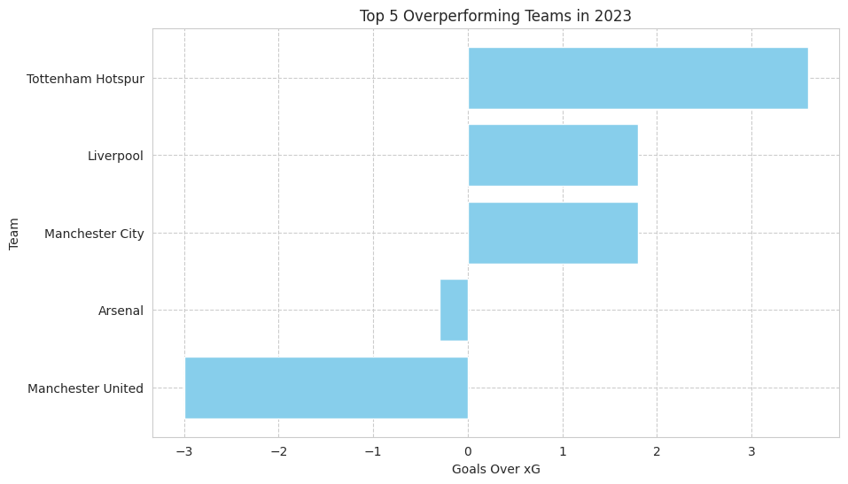

```python
df2 = df[df['team'].isin(top)]

df2['goals_over_xG'] = df2['goals_scored'] - df2['expected_goals']

# Group data by year (season) and team, and calculate the total goals over xG
grouped = df2.groupby(['season', 'team'])['goals_over_xG'].sum().reset_index()

# Sort the data by season and goals over xG in descending order
sorted_data = grouped.sort_values(by=['season', 'goals_over_xG'], ascending=[True, False])

# Get the top 5 overperforming teams for each year
top_teams = sorted_data.groupby('season').head(5)

# Create visualizations for each year
for year, group in top_teams.groupby('season'):
    plt.figure(figsize=(10, 6))
    plt.barh(group['team'], group['goals_over_xG'], color='skyblue')
    plt.xlabel('Goals Over xG')
    plt.ylabel('Team')
    plt.title(f'Top 5 Overperforming Teams in {year}')
    plt.gca().invert_yaxis()  # Reverse the order of teams for better visualization
    plt.show()
```

##### *Part 2: Identifying Top 5 Overperforming Teams Combined for All Seasons*

Here, we aggregate data across multiple seasons to spot teams that have consistently outperformed their xG expectations. We compute the cumulative Goals Scored and xG for each team across all seasons and ascertain the teams with the greatest collective positive differences between Goals Scored and xG.

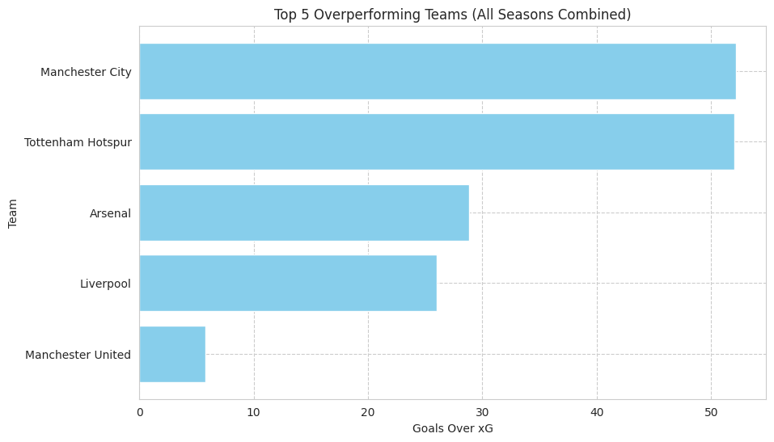

```python
grouped = df2.groupby('team')['goals_over_xG'].sum().reset_index()

# Sort the data by goals over xG in descending order
sorted_data = grouped.sort_values(by='goals_over_xG', ascending=False)

# Get the top 5 overperforming teams for all seasons combined
top_teams = sorted_data.head(5)

# Create a visualization for the top overperforming teams
plt.figure(figsize=(10, 6))
plt.barh(top_teams['team'], top_teams['goals_over_xG'], color='skyblue')
plt.xlabel('Goals Over xG')
plt.ylabel('Team')
plt.title('Top 5 Overperforming Teams (All Seasons Combined)')
plt.gca().invert_yaxis()  # Reverse the order of teams for better visualization
plt.show()
```

*Description*

- Both parts of the analysis incorporate visualizations in the form of bar charts. These charts showcase the top overperforming teams for each season (Part 1) and the top overperforming teams across all seasons (Part 2). They provide a clear representation of which teams have consistently demonstrated superior goal-scoring capabilities in relation to their xG expectations.
- Manchester City has the most goals over xG which is somewhat expected as they scored the most goals.

Now, let's analyse it differently.

#### Using Percentage Terms for Overperformance Analysis

In our ongoing analysis, we have made a significant adjustment in the way we assess teams' overperformance relative to Expected Goals (xG). Rather than relying solely on total overperformance values, we have transitioned to using percentage terms. This shift offers a more meaningful and equitable basis for comparison across seasons and teams. Here's why percentage terms are a better choice for comparison:

**1. Standardized Assessment:** Total overperformance values may be influenced by the volume of scoring opportunities a team encounters in a given season. Teams with more opportunities are likely to have higher total overperformance figures. By calculating percentage overperformance, we standardize the assessment, enabling fair comparisons irrespective of variations in opportunities.

**2. Reflecting Efficiency:** Percentage overperformance provides insights into a team's efficiency in front of the goal. It gauges a team's ability to make the most of the opportunities they create, which is a key indicator of offensive prowess.

**3. Comparative Analysis:** Using percentage terms allows us to evaluate teams on a level playing field, making it easier to identify consistent overperformers across different seasons. This approach helps us pinpoint teams that consistently excel in converting opportunities into goals, regardless of the total number of chances.

Now, let's proceed to examine the results of our analysis using percentage terms for overperformance:

##### *Part 1: Identifying Top 5 Overperforming Teams Each Year (Percentage Terms)*

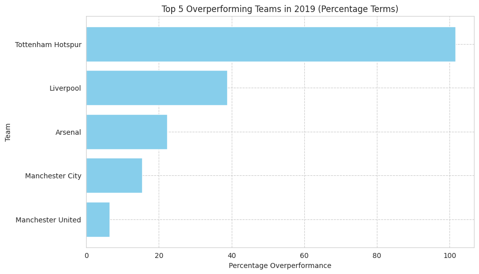

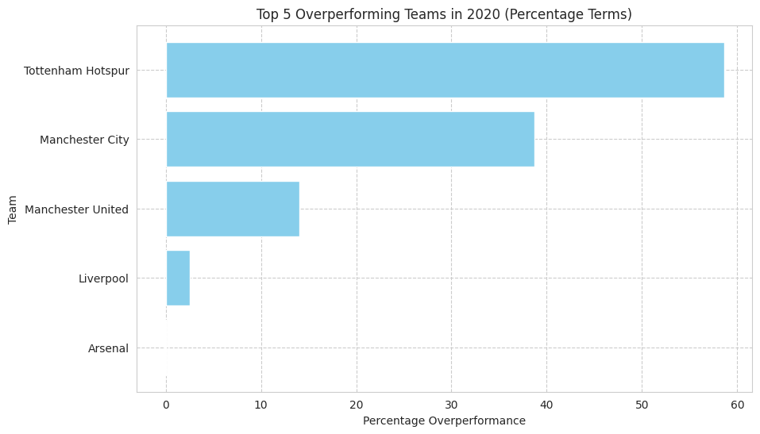

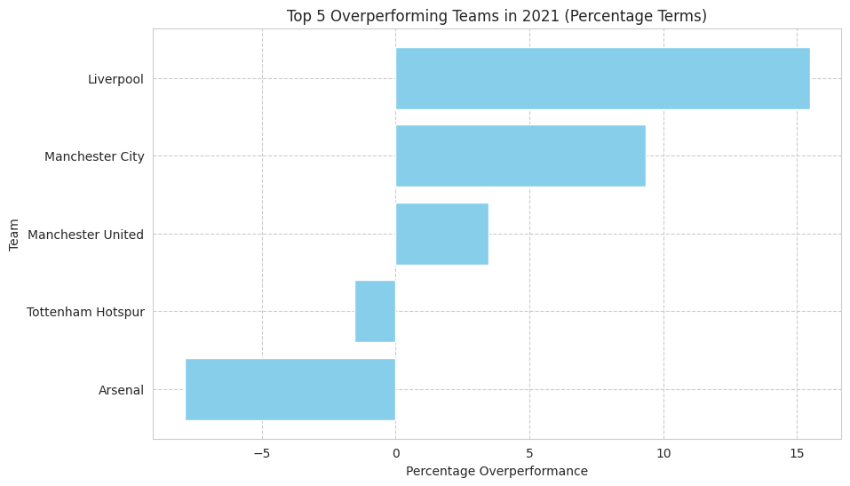

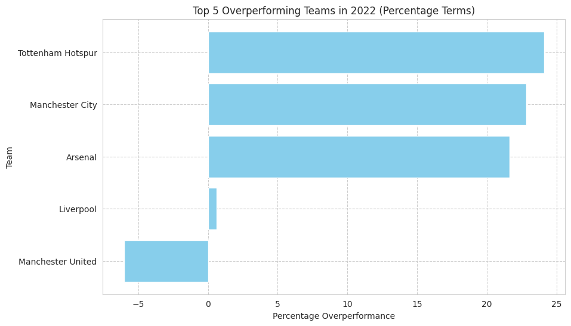

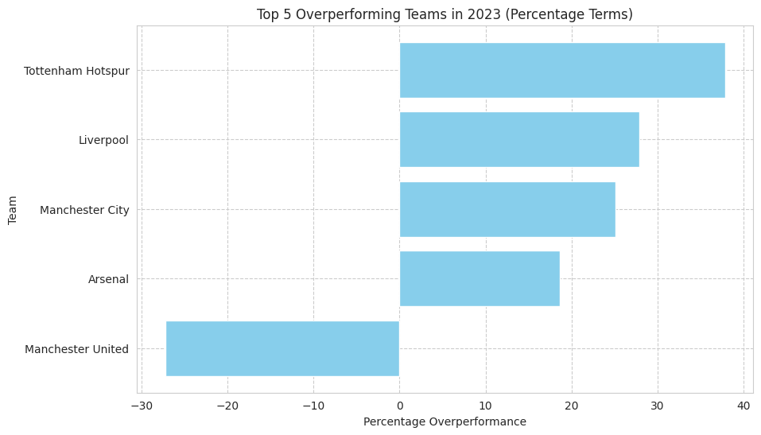

```python
df2['percentage_overperformance'] = ((df2['goals_scored'] - df2['expected_goals']) / df2['expected_goals']) * 100

# Group data by year (season) and team, and calculate the mean percentage overperformance
grouped = df2.groupby(['season', 'team'])['percentage_overperformance'].mean().reset_index()

# Sort the data by season and percentage overperformance in descending order
sorted_data = grouped.sort_values(by=['season', 'percentage_overperformance'], ascending=[True, False])

# Get the top 5 overperforming teams for each year
top_teams = sorted_data.groupby('season').head(5)

# Create visualizations for the top overperforming teams
for year, group in top_teams.groupby('season'):
    plt.figure(figsize=(10, 6))
    plt.barh(group['team'], group['percentage_overperformance'], color='skyblue')
    plt.xlabel('Percentage Overperformance')
    plt.ylabel('Team')
    plt.title(f'Top 5 Overperforming Teams in {year} (Percentage Terms)')
    plt.gca().invert_yaxis()  # Reverse the order of teams for better visualization
    plt.show()
```

##### *Part 2: Identifying Top 5 Overperforming Teams Combined for All Seasons (Percentage Terms)*

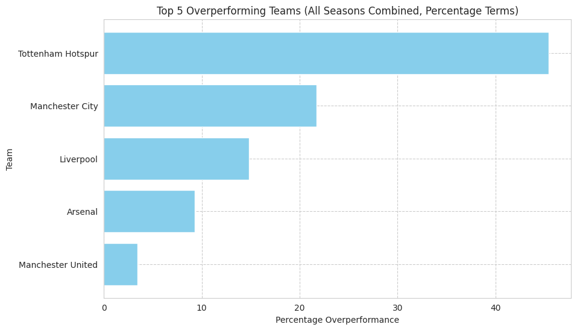

```python
df2['percentage_overperformance'] = ((df2['goals_scored'] - df2['expected_goals']) / df2['expected_goals']) * 100

# Group data by team and calculate the mean percentage overperformance
grouped = df2.groupby('team')['percentage_overperformance'].mean().reset_index()

# Sort the data by percentage overperformance in descending order
sorted_data = grouped.sort_values(by='percentage_overperformance', ascending=False)

# Get the top 5 overperforming teams for all seasons combined
top_teams = sorted_data.head(5)

# Create a visualization for the top overperforming teams
plt.figure(figsize=(10, 6))
plt.barh(top_teams['team'], top_teams['percentage_overperformance'], color='skyblue')
plt.xlabel('Percentage Overperformance')
plt.ylabel('Team')
plt.title('Top 5 Overperforming Teams (All Seasons Combined, Percentage Terms)')
plt.gca().invert_yaxis()  # Reverse the order of teams for better visualization
plt.show()
```

#### Shooting Skill and Precision

```python
# 'shots': Shots taken by team and 'shots_on_target': Shots on target by team
ttl_shots = df2.groupby(['team'])['shots'].sum()
ttl_success_shots = df2.groupby(['team'])['shots_on_target'].sum()

shots_success_percent = ttl_success_shots/ttl_shots*100
shots_success_percent.sort_values(ascending=False, inplace=True)
shots_success_percent
```

```
team
Tottenham Hotspur    36.975215
Manchester United    36.281588
Manchester City      34.672071
Liverpool            34.401544
Arsenal              32.968601
dtype: float64
```

#### Blocking Opponent Goals and Defense

This section focuses on exploring the percentage of goals successfully blocked/conceded by a team. This can be used as a measure of the skill of the team's goalkeeper or more generally the defence skill of the team as a whole.

```python
# 'goals_conceded': goals blocked by team
ttl_goals_conceded = df2.groupby(['team'])['goals_conceded'].sum()
ttl_goals_conceded
```

```
team
Arsenal              182.0
Liverpool            152.0
Manchester City      129.0
Manchester United    190.0
Tottenham Hotspur    200.0
Name: goals_conceded, dtype: float64
```

```python
ttl_goals_scored = df[df['opponent'].isin(top)].groupby(['opponent'])['shots'].sum()
ttl_goals_scored.index.name = 'team'
ttl_goals_scored
```

```
team
Arsenal              1759.0
Liverpool            1393.0
Manchester City      1108.0
Manchester United    1871.0
Tottenham Hotspur    2080.0
Name: shots, dtype: float64
```

```python
df_goals_sc_cond = pd.merge(ttl_goals_scored, ttl_goals_conceded, on='team', how='inner')
df_goals_sc_cond.columns={'Goals Scored', 'Goals Conceded'}
df_goals_sc_cond
```

| team | Goals Conceded | Goals Scored |
| --- | --- | --- |
| Arsenal | 1759.0 | 182.0 |
| Liverpool | 1393.0 | 152.0 |
| Manchester City | 1108.0 | 129.0 |
| Manchester United | 1871.0 | 190.0 |
| Tottenham Hotspur | 2080.0 | 200.0 |

```python
df_goals_sc_cond['shots_success_percent'] = df_goals_sc_cond['Goals Scored']/df_goals_sc_cond['Goals Conceded']*100
df_goals_sc_cond.sort_values(by = 'shots_success_percent', ascending=False, inplace=True)
df_goals_sc_cond
```

| team | Goals Conceded | Goals Scored | shots_success_percent |
| --- | --- | --- | --- |
| Manchester City | 1108.0 | 129.0 | 11.642599 |
| Liverpool | 1393.0 | 152.0 | 10.911701 |
| Arsenal | 1759.0 | 182.0 | 10.346788 |
| Manchester United | 1871.0 | 190.0 | 10.154997 |
| Tottenham Hotspur | 2080.0 | 200.0 | 9.615385 |

### Hypothesis Testing

[Manchester City Official's Website](https://www.mancity.com/news/mens/man-city-premier-league-stats-202223-63820961#:~:text=City%20scored%20a%20whopping%2094,league%20games%20in%202022%2F23) claims that the average number of goals scored by Arsenal is 2.31. Based on the current dataset, the average goals scored by Arsenal is:

```python
df[(df["team"] == "Arsenal")]["goals_scored"].mean()
```

```
1.713375796178344
```

with sample size

```python
df[(df["team"] == "Arsenal")]["goals_scored"].count()
```

```
157
```

It may seem like a big difference. But could it have been by chance? Can we conclude that the average goals scored by arsenal in our sample is not equal to population?

#### Hypothesis Test 1:

To answer the previous question, a one-sample test will be performed in the following setup:

- $H_0: \mu = 2.31$,
- $H_1 : \mu \neq 2.31$,

where the sample mean $\bar{X}$ is the test statistic and $\bar{x} = 1.71$, $n=157$.

If the true mean is really 2.31, what is the probability of getting values of $\bar{X}$ at least as contradictory to μ = 2.31 as $\bar{x}$ = 1.71, for a random sample of the same size and variance? So ”at least as contradictory” is at least as far away from 2.31 as 1.71.

```python
arsenal_goals_scored =df[(df["team"] == "Arsenal") ]["goals_scored"]
from scipy import stats
answer= stats.ttest_1samp(a = arsenal_goals_scored, popmean = 2.31)

if answer[1] < 0.05:
  print("Reject the null hypothesis")
else:
  print("Hypothesis can not be rejected")
print("The P-value is "+ str(answer[1]) )
print("The  test statistics "+str(answer[0]))
answer
```

```
Reject the null hypothesis
The P-value is 9.485911045404651e-08
The  test statistics -5.599006952234918
```

```
TtestResult(statistic=-5.599006952234918, pvalue=9.485911045404651e-08, df=156)
```

```python
import numpy as np
```

```python
import scipy.stats as st
import numpy as np

confidence_level = 0.95
degreef = len(arsenal_goals_scored) - 1
mean_goals_scored = np.mean(arsenal_goals_scored)
standard_error = st.sem(arsenal_goals_scored)

# Use confidence level instead of alpha
interval = st.t.interval(confidence_level, df=degreef, loc=mean_goals_scored, scale=standard_error)

print("Confidence Interval:", interval)
```

```
Confidence Interval: (1.5028912680019217, 1.9238603243547663)
```

- The p-value is very small (less than $\alpha = 0.05$) which means we reject the Null Hypothesis. This means that there is a significant difference between the sample mean and the hypothesized population mean.

The statistical analysis conducted on the dataset for the average number of goals scored by Arsenal yielded the following results:

1. **P-value:** $(9.49 \times 10^{-8})$ - This extremely small p-value provides strong evidence against the null hypothesis $(H_0: \mu = 2.31)$, suggesting that the average number of goals scored by Arsenal is significantly different from 2.31.
2. **Test Statistic:** $(-5.60)$ - The negative test statistic indicates a deviation from the hypothesized mean, and its magnitude underscores the strength of the evidence against the null hypothesis.
3. **Confidence Interval:** $(1.50, 1.92)$ - The confidence interval doesn't include the hypothesized mean of 2.31, providing further support for rejecting the null hypothesis.

In conclusion, based on the low p-value, the negative test statistic, and the confidence interval, there is robust evidence to reject the null hypothesis. This implies that the average number of goals scored by Arsenal, according to the dataset, differs significantly from the claimed value of 2.31.

#### Hypothesis Test 2:

$ \text{We have a dataset examining possession differences in 2022 vs 2019 for Arsenal.} \\ \text{We are interested in finding strong evidence that there this significtent increase in the possession in year 2022 i.e} \quad μ_d > 0 \\ \text{so the null hypothesis is that there is no significetent difference i.e} \quad μ_D = 0 $

$H_O : μ_D = 0 $

$ H_A: μ_D> 0 $

```python
Shots2022 = df[(df["season"]== 2022) &
 (df["team"] == "Arsenal")]["possession"]

Shots2019 = df[(df["season"]== 2019) &
 (df["team"] == "Arsenal")]["possession"]
```

```python
stats.ttest_rel(Shots2022, Shots2019)
```

```
TtestResult(statistic=2.2258839284082166, pvalue=0.03219630906750623, df=37)
```